# US Regions Views of Technology and Employement Characteristics

A national survey was conducted by Pew Research Center in conjunction with Smithsonian magazine between February 13-18, 2014 by landline and cell phones among 1,001 adults. The objective of the survey was to better understand US views towards scientific and technological changes and how they viewed the future. Understanding public perception of these types of changes occurring in the US is important to understand how Americans view their place in the changing environment and if they are hopeful or anxious about the future.

The questions regarding scientific and technological changes were varied and include some issues currently being discussed today, such as “would you ride in a driver-less car?”. In the below table we see that 51.3% of individuals in the survey were willing to ride in a driver-less car.

Pew Research Question : would you ride in a driver-less car?

| Yes, would do this | No, would not do this | Refused | Don’t know |
| --- | --- | --- | --- |
| 514 | 460 | 1 | 26 |

However, if we look at a map of a recent analysis by [NPR’s Planet Money](http://www.npr.org/sections/money/2015/02/05/382664837/map-the-most-common-job-in-every-state) [1] on census data of the same time period we see that the most common job in most states is truck driver. This type of employment may be made obsolete as more and more individuals become comfortable with driver-less vehicles. Unfortunately, changes and comfort with driver-less cars will inevitably lead to driver-less trucks.

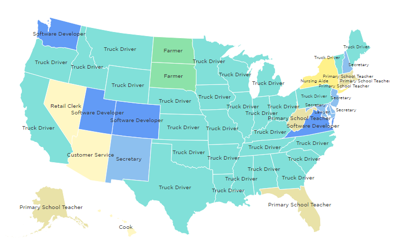

## Regional Differences

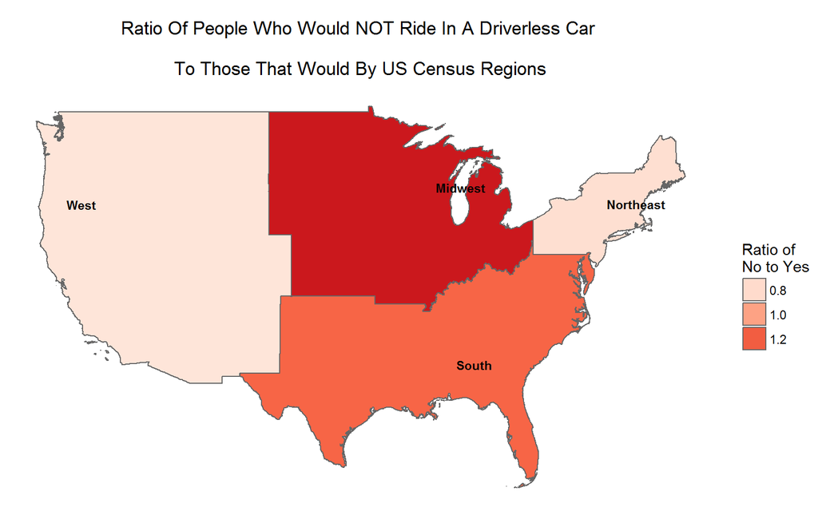

Interestingly, we do see a higher ratio of people that would not ride in a driverless car regions were most individuals are trucker drivers. It does seem that there is a correlation with a negative response to a question that threatens the predominate occupation in a region.

[interactive chart not shown]

```python
from plotly import __version__
from plotly.offline import download_plotlyjs, init_notebook_mode, plot, iplot
from plotly.graph_objs import Scatter, Figure, Layout

plot([Scatter(x=[1, 2, 3], y=[3, 1, 6])])
```

Employment Data Source: U.S. Census Bureau, 2010-2014 American Community Survey 5-Year Estimates

Technology Views Data Source: Pew Research Center, April, 2014, “U.S. Views of Technology and the Future” Available at: http://www.pewinternet.org/2014/04/17/us-views-of-technology-and-the-future/

Note: *The Pew Research Center bears no responsibility for the interpretations presented or conclusions reached based on analysis of the data.*

[1] “Map: The Most Common* Job In Every State.” NPR. NPR, n.d. Web. 03 Dec. 2016.